## Import Library

```r
library(tidyverse)
library(data.table)
library(readxl)
library(gridExtra)
library(reshape2)
library(agricolae)
```

## Load Data

```r
customer <- read_excel("월별소비자동향조사.xlsx")
head(customer)
```

```
## # A tibble: 6 x 38
##   지수코드별 분류코드별 항목  단위  `2018. 01 월` `2018. 02 월` `2018. 03 월`
##   <chr>      <chr>      <chr> <lgl>         <dbl>         <dbl>         <dbl>
## 1 현재생활형편CSI~ 전체       소비자동~ NA               94            94            95
## 2 현재생활형편CSI~ 남자       소비자동~ NA               94            94            95
## 3 현재생활형편CSI~ 여자       소비자동~ NA               95            94            95
## 4 현재생활형편CSI~ 40세미만   소비자동~ NA               96            98            99
## 5 현재생활형편CSI~ 40-50세    소비자동~ NA               96            93            96
## 6 현재생활형편CSI~ 50-60세    소비자동~ NA               93            95            95
## # ... with 31 more variables: `2018. 04 월` <dbl>, `2018. 05 월` <dbl>, `2018.
## #   06 월` <dbl>, `2018. 07 월` <dbl>, `2018. 08 월` <dbl>, `2018. 09
## #   월` <dbl>, `2018. 10 월` <dbl>, `2018. 11 월` <dbl>, `2018. 12 월` <dbl>,
## #   `2019. 01 월` <dbl>, `2019. 02 월` <dbl>, `2019. 03 월` <dbl>, `2019. 04
## #   월` <dbl>, `2019. 05 월` <dbl>, `2019. 06 월` <dbl>, `2019. 07 월` <dbl>,
## #   `2019. 08 월` <dbl>, `2019. 09 월` <dbl>, `2019. 10 월` <dbl>, `2019. 11
## #   월` <dbl>, `2019. 12 월` <dbl>, `2020. 01 월` <dbl>, `2020. 02 월` <dbl>,
## #   `2020. 03 월` <dbl>, `2020. 04 월` <dbl>, `2020. 05 월` <dbl>, `2020. 06
## #   월` <dbl>, `2020. 07 월` <dbl>, `2020. 08 월` <dbl>, `2020. 09 월` <dbl>,
## #   `2020. 10 월` <dbl>
```

```r
customer<-customer %>%
  select(-c("항목","단위"))

customer_age <- customer %>% filter(grepl('세+',분류코드별))
customer_age
```

```
## # A tibble: 120 x 36
##    지수코드별 분류코드별 `2018. 01 월` `2018. 02 월` `2018. 03 월` `2018. 04 월`
##    <chr>      <chr>              <dbl>         <dbl>         <dbl>         <dbl>
##  1 현재생활형편CSI~ 40세미만              96            98            99           100
##  2 현재생활형편CSI~ 40-50세               96            93            96            95
##  3 현재생활형편CSI~ 50-60세               93            95            95            94
##  4 현재생활형편CSI~ 60-70세               91            91            93            90
##  5 현재생활형편CSI~ 70세이상              87            90            87            87
##  6 현재경기판단CSI~ 40세미만              93            94            93            95
##  7 현재경기판단CSI~ 40-50세               93            91            90            87
##  8 현재경기판단CSI~ 50-60세               88            87            85            85
##  9 현재경기판단CSI~ 60-70세               84            81            78            76
## 10 현재경기판단CSI~ 70세이상              79            79            79            77
## # ... with 110 more rows, and 30 more variables: `2018. 05 월` <dbl>, `2018. 06
## #   월` <dbl>, `2018. 07 월` <dbl>, `2018. 08 월` <dbl>, `2018. 09 월` <dbl>,
## #   `2018. 10 월` <dbl>, `2018. 11 월` <dbl>, `2018. 12 월` <dbl>, `2019. 01
## #   월` <dbl>, `2019. 02 월` <dbl>, `2019. 03 월` <dbl>, `2019. 04 월` <dbl>,
## #   `2019. 05 월` <dbl>, `2019. 06 월` <dbl>, `2019. 07 월` <dbl>, `2019. 08
## #   월` <dbl>, `2019. 09 월` <dbl>, `2019. 10 월` <dbl>, `2019. 11 월` <dbl>,
## #   `2019. 12 월` <dbl>, `2020. 01 월` <dbl>, `2020. 02 월` <dbl>, `2020. 03
## #   월` <dbl>, `2020. 04 월` <dbl>, `2020. 05 월` <dbl>, `2020. 06 월` <dbl>,
## #   `2020. 07 월` <dbl>, `2020. 08 월` <dbl>, `2020. 09 월` <dbl>, `2020. 10
## #   월` <dbl>
```

## 코로나 이전 이후의 행별 평균

```r
customer_base <- customer_age[1:2]
bf_age <- customer_age[3:27]
af_age <- customer_age[28:36]

bf_age <- customer_base %>% bind_cols(bf_age)
af_age <- customer_base %>% bind_cols(af_age)

bf_age <- bf_age %>% cbind(data.frame(평균 = apply(bf_age[, 3:27], 1, mean)))
af_age <- af_age %>% cbind(data.frame(평균 = apply(af_age[, 3:11], 1, mean)))
```

```r
head(bf_age)
```

```
##        지수코드별 분류코드별 2018. 01 월 2018. 02 월 2018. 03 월 2018. 04 월
## 1 현재생활형편CSI   40세미만          96          98          99         100
## 2 현재생활형편CSI    40-50세          96          93          96          95
## 3 현재생활형편CSI    50-60세          93          95          95          94
## 4 현재생활형편CSI    60-70세          91          91          93          90
## 5 현재생활형편CSI   70세이상          87          90          87          87
## 6 현재경기판단CSI   40세미만          93          94          93          95
##   2018. 05 월 2018. 06 월 2018. 07 월 2018. 08 월 2018. 09 월 2018. 10 월
## 1          98          99          93          92          96          94
## 2          96          94          94          90          92          95
## 3          95          92          90          87          89          87
## 4          93          90          87          84          85          88
## 5          89          88          88          85          86          91
## 6          97          95          86          77          74          74
##   2018. 11 월 2018. 12 월 2019. 01 월 2019. 02 월 2019. 03 월 2019. 04 월
```

[output cut: 20 more lines]

```r
head(af_age)
```

```
##        지수코드별 분류코드별 2020. 02 월 2020. 03 월 2020. 04 월 2020. 05 월
## 1 현재생활형편CSI   40세미만          96          90          87          87
## 2 현재생활형편CSI    40-50세          96          85          77          81
## 3 현재생활형편CSI    50-60세          90          79          73          74
## 4 현재생활형편CSI    60-70세          85          79          73          76
## 5 현재생활형편CSI   70세이상          84          77          71          77
## 6 현재경기판단CSI   40세미만          76          42          37          41
##   2020. 06 월 2020. 07 월 2020. 08 월 2020. 09 월 2020. 10 월     평균
## 1          90          90          91          87          92 90.00000
## 2          86          87          86          83          89 85.55556
## 3          77          82          83          78          83 79.88889
## 4          81          82          83          77          81 79.66667
## 5          84          84          81          77          80 79.44444
## 6          48          53          59          44          63 51.44444
```

## 공백이 포함된 CSI 지수 제거

```r
bf_age <- bf_age %>% filter(!grepl(' ', 지수코드별))
af_age <- af_age %>% filter(!grepl(' ', 지수코드별))
head(bf_age)
```

```
##        지수코드별 분류코드별 2018. 01 월 2018. 02 월 2018. 03 월 2018. 04 월
## 1 현재생활형편CSI   40세미만          96          98          99         100
## 2 현재생활형편CSI    40-50세          96          93          96          95
## 3 현재생활형편CSI    50-60세          93          95          95          94
## 4 현재생활형편CSI    60-70세          91          91          93          90
## 5 현재생활형편CSI   70세이상          87          90          87          87
## 6 현재경기판단CSI   40세미만          93          94          93          95
##   2018. 05 월 2018. 06 월 2018. 07 월 2018. 08 월 2018. 09 월 2018. 10 월
## 1          98          99          93          92          96          94
## 2          96          94          94          90          92          95
## 3          95          92          90          87          89          87
## 4          93          90          87          84          85          88
## 5          89          88          88          85          86          91
## 6          97          95          86          77          74          74
##   2018. 11 월 2018. 12 월 2019. 01 월 2019. 02 월 2019. 03 월 2019. 04 월
```

[output cut: 20 more lines]

```r
unique(bf_age[1])
```

```
##                지수코드별
## 1         현재생활형편CSI
## 6         현재경기판단CSI
## 11        생활형편전망CSI
## 16        향후경기전망CSI
## 21        취업기회전망CSI
## 26        금리수준전망CSI
## 31        가계수입전망CSI
## 36        소비지출전망CSI
## 41        현재가계저축CSI
## 46        가계저축전망CSI
## 51        현재가계부채CSI
## 56        가계부채전망CSI
## 61 물가수준전망(1년후)CSI
## 66        주택가격전망CSI
## 71        임금수준전망CSI
```

## bar-graph를 그리기 위한 컬럼 선택

```r
bf_hal <- bf_age %>% filter(지수코드별 %in% c("현재생활형편CSI","소비지출전망CSI"))
af_hal <- af_age %>% filter(지수코드별 %in% c("현재생활형편CSI","소비지출전망CSI"))
```

## 코로나 이전, 이후를 나타내는 group 변추 추가

## 현재생활형편, 소비지출전망 나누기

```r
bf_hal <- bf_hal %>% mutate(group = "1")
af_hal <- af_hal %>% mutate(group = "2")
bf_hal <- bf_hal %>% select(c("지수코드별","분류코드별","평균","group"))
af_hal <- af_hal %>% select(c("지수코드별","분류코드별","평균","group"))
df <- bf_hal %>% bind_rows(af_hal)
routine <- df %>% filter(지수코드별 == "현재생활형편CSI")
consume <- df %>% filter(지수코드별 == "소비지출전망CSI")
```

## 그래프 객체 만들기 및 그리기

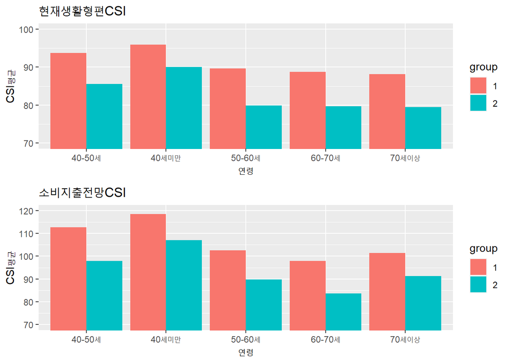

```r
routinep = ggplot(routine, aes(x = 분류코드별, y = 평균, fill = group)) +
  geom_bar(stat = "identity",position = "dodge") +
  labs(x = "연령", y = "CSI평균") +
  ggtitle("현재생활형편CSI") +
  coord_cartesian(ylim = c(70, 100))


consumep = ggplot(consume, aes(x = 분류코드별, y = 평균, fill = group)) +
  geom_bar(stat = "identity",position = "dodge") +
  labs(x = "연령", y = "CSI평균") +
  ggtitle("소비지출전망CSI") +
  coord_cartesian(ylim = c(70, 120))

grid.arrange(routinep,consumep, nrow = 2, ncol = 1)
```

### 여기서부터는 연령별 CSI 종류 분산분석

### _-------------------------------------------------------------------------------

## 소득별 데이터 나누기

```r
customer <- read_excel("월별소비자동향조사.xlsx")

data1 <- customer %>%
  filter(분류코드별 %in% c('자영업자', '봉급생활자')) %>%
  filter(지수코드별 %in% c('임금수준전망CSI', '현재생활형편CSI',
                      '현재경기판단CSI', '생활형편전망CSI', '향후경기전망CSI')) %>%
  select(-항목, -단위) %>%
  melt(id.vars=c('지수코드별', '분류코드별'))

data1$지수코드별 = as.factor(data1$지수코드별)
data1$분류코드별 = as.factor(data1$분류코드별)

data1_b <- data1[c(1:240), ]
data1_a <- data1[c(241:340), ]

category = c('가계수입전망CSI', '현재가계저축CSI',
             '가계저축전망CSI', '주택가격전망CSI',
             '소비지출전망CSI', '의료·보건비 지출전망CSI',
             '교양·오락·문화생활비 지출전망CSI', '의류비 지출전망CSI',
             '외식비 지출전망CSI', '여행비 지출전망CSI', '교육비 지출전망CSI')

data_wage <- customer %>%
  filter(grepl('만원+',분류코드별)) %>%
  filter(지수코드별 %in% category) %>%
  select(-항목, -단위) %>%
  melt(id.vars=c('지수코드별', '분류코드별')) %>%
  mutate(지수코드별 = as.factor(지수코드별), 분류코드별 = as.factor(분류코드별))
```

```r
data_wage_b <- data_wage[c(1:1650), ]
data_wage_a <- data_wage[c(1650:2244), ]
```

## 연령별 데이터 나누기

```r
data2 <- customer %>%
  filter(grepl('세+',분류코드별)) %>%
  filter(지수코드별 %in% category) %>%
  select(-항목, -단위) %>%
  melt(id.vars=c('지수코드별', '분류코드별')) %>%
  mutate(지수코드별 = as.factor(지수코드별), 분류코드별 = as.factor(분류코드별))
```

```r
data2_b <- data2[c(1:1375), ]
data2_a <- data2[c(1376:1870), ]
```

## Anova 함수 구현

```r
anova_result = function(df, category) {

  aov_list = list()
  summary_list = list()
  posthoc_list = list()

  for (i in 1:length(category)){
    aov_model = aov(value ~ 분류코드별 + variable,
                    data=df[df$지수코드별 == category[i], ])
    aov_list[[i]] = aov_model

    summary_list[[i]] = summary(aov_model)

    posthoc = HSD.test(aov_model, '분류코드별', group=TRUE)
    posthoc_list[[i]] = posthoc
  }

  return(list('aov' = aov_list, 'summary' = summary_list, 'posthoc' = posthoc_list))

}
```

## 연령별, 소득별 anova결과 리스트 저장

```r
anova_result_before = anova_result(df=data2_b, category=category)
anova_result_after = anova_result(df=data2_a, category=category)

anova_result_before_wage = anova_result(df = data_wage_b, category = category)
anova_result_after_wage = anova_result(df = data_wage_a, category = category)
```

## anova 결과 출력(연령별)

```r
for (i in 1:length(category)){
  cat('\n', category[i], '에 대한 분산분석 결과입니다.\n\n')
  print(anova_result_before$summary[[i]])
  print(anova_result_before$posthoc[[i]])
  print(anova_result_after$summary[[i]])
  print(anova_result_after$posthoc[[i]])
}
```

```
##
##  가계수입전망CSI 에 대한 분산분석 결과입니다.
##
##             Df Sum Sq Mean Sq F value   Pr(>F)
## 분류코드별   4   4480  1119.9 352.164  < 2e-16 ***
## variable    24    610    25.4   7.993 4.68e-14 ***
## Residuals   96    305     3.2
## ---
## Signif. codes:  0 '***' 0.001 '**' 0.01 '*' 0.05 '.' 0.1 ' ' 1
## $statistics
##   MSerror Df  Mean       CV      MSD
##      3.18 96 97.56 1.827855 1.402332
##
## $parameters
##    test     name.t ntr StudentizedRange alpha
##   Tukey 분류코드별   5         3.931944  0.05
##
## $means
##           value      std  r Min Max Q25 Q50 Q75
## 40-50세  102.56 2.501333 25  98 108 101 103 104
## 40세미만 106.24 2.026491 25 103 112 105 106 107
## 50-60세   96.28 3.553402 25  91 105  94  95  98
## 60-70세   91.76 3.112876 25  87  98  89  91  95
## 70세이상  90.96 2.335951 25  87  95  89  91  93
##
## $comparison
## NULL
##
## $groups
##           value groups
## 40세미만 106.24      a
## 40-50세  102.56      b
## 50-60세   96.28      c
## 60-70세   91.76      d
## 70세이상  90.96      d
##
## attr(,"class")
## [1] "group"
##             Df Sum Sq Mean Sq F value  Pr(>F)
## 분류코드별   4 1565.6   391.4  124.81 < 2e-16 ***
```

[output cut: 748 more lines]

```
## 70세이상  86.00000 3.082207 9  81  92  85  86  87
##
## $comparison
## NULL
##
## $groups
##              value groups
## 40-50세  107.88889      a
## 40세미만 101.66667      b
## 50-60세   91.66667      c
## 70세이상  86.00000      d
## 60-70세   82.33333      e
##
## attr(,"class")
## [1] "group"
```

## anova 결과 출력(소득별)

```r
for (i in 1:length(category)){
  cat('\n', category[i], '에 대한 분산분석 결과입니다.\n\n')
  print(anova_result_before_wage$summary[[i]])
  print(anova_result_before_wage$posthoc[[i]])
  print(anova_result_after_wage$summary[[i]])
  print(anova_result_after_wage$posthoc[[i]])
}
```

```
##
##  가계수입전망CSI 에 대한 분산분석 결과입니다.
##
##              Df Sum Sq Mean Sq F value   Pr(>F)
## 분류코드별    5   4206   841.2 197.037  < 2e-16 ***
## variable     24    826    34.4   8.066 1.33e-15 ***
## Residuals   120    512     4.3
## ---
## Signif. codes:  0 '***' 0.001 '**' 0.01 '*' 0.05 '.' 0.1 ' ' 1
## $statistics
##    MSerror  Df     Mean       CV      MSD
##   4.269111 120 97.20667 2.125557 1.692611
##
## $parameters
##    test     name.t ntr StudentizedRange alpha
##   Tukey 분류코드별   6         4.095986  0.05
##
## $means
##              value      std  r Min Max Q25 Q50 Q75
## 100-200만원  92.88 3.004441 25  88 100  91  92  95
## 100만원미만  88.24 3.205204 25  81  96  87  88  90
## 200-300만원  97.72 2.491987 25  93 103  96  97  99
## 300-400만원  98.60 3.366502 25  94 106  96  98 101
## 400-500만원 101.88 3.395095 25  96 109  99 102 105
## 500만원이상 103.92 2.722132 25 100 111 102 103 105
##
## $comparison
## NULL
##
## $groups
##              value groups
## 500만원이상 103.92      a
## 400-500만원 101.88      b
## 300-400만원  98.60      c
## 200-300만원  97.72      c
## 100-200만원  92.88      d
## 100만원미만  88.24      e
##
## attr(,"class")
## [1] "group"
```

[output cut: 792 more lines]

```
##
## $comparison
## NULL
##
## $groups
##                 value groups
## 500만원이상 102.77778      a
## 400-500만원 100.44444     ab
## 300-400만원  97.77778      b
## 200-300만원  90.88889      c
## 100-200만원  86.00000      d
## 100만원미만  78.22222      e
##
## attr(,"class")
## [1] "group"
```

# 결과 해석 및 인사이트

### 소득별 분산분석

총평 : 코로나의 발생이 저소득층에게 치명적으로 다가온다는 것(가계 수입 전망, 현재 가계 저축, 가계 저축 전망) <-- 문제로 생각해볼 수 있을 듯.  
여행에 관련된 부분의 영향이 컸다는 것.  
문화생활에서는 고소득층의 문화생활이 크게 감소했다는 점.  
의료보건비에서 역시 저소득층이 부담을 크게 느끼는 것이 아닐까하는 생각.  
고소득층 보다 저소득층이 주택 가격을 높게 전망함, 코로나 이후 역시 같은 경향.

나름껏 추려낸 지표 : 여행비, 주택가격전망, 교양 오락 문화생활비, 의료 보건비, (수입, 저축전망, 소비지출)

### 연령별 분산분석

정리

총평 : 전반적으로 코로나의 발생으로 연령대별 소비가 크게 준 것을 확인할 수 있다.  
의료보건비에서 70대 이상의 지출 부담을 크게 느끼는 것이 아닐까 하는 생각  
교육비가 양육의 여부에 따라서 감소폭이 달랐다는 점이 신기했다.  
여행과 관련된 부분의 영향이 컸다는 것.  
주택 가격은 40대 미만, 70대 이상의 전망수치가 크게 높다. 코로나 이후는 더 높아짐.

나름껏 추려낸 지표 : 여행비, 교육비, (수입, 저축전망, 소비지출), 주택가격전망, 의료 보건비